# Titanic Feature Engineering Analysis: Cabin, Fare, and Embarkation Port

Author

CLI Copilot

# Executive Summary

This report investigates three critical feature engineering questions for the Titanic dataset: 1. **Cabin and Deck Information**: Does extracting deck from cabin add predictive power beyond class and fare? 2. **Fare as Wealth Proxy**: Is fare independent signal or merely a proxy for passenger class within socio-economic tiers? 3. **Port of Embarkation**: Does port of embarkation have survival signal after accounting for passenger composition?

The analysis combines exploratory data analysis (EDA) to understand relationships, followed by statistical modeling to quantify predictive gain from each feature addition.

# Setup and Data Loading

```r
library(tidyverse)
library(knitr)
library(patchwork)

# Set ggplot theme for consistency
theme_set(
  theme_minimal() +
    theme(
      plot.title = element_text(face = "bold", size = 12),
      plot.subtitle = element_text(size = 10, color = "grey40"),
      legend.position = "bottom",
      panel.grid.minor = element_blank()
    )
)

# Read data
train_df <- read_csv("/Users/patrickl/Developer/Personal-Repo/cli_poc_ml_project/data/train.csv")
test_df <- read_csv("/Users/patrickl/Developer/Personal-Repo/cli_poc_ml_project/data/test.csv")

cat("Training data shape:", dim(train_df)[1], "x", dim(train_df)[2], "\n")
```

```
Training data shape: 891 x 12
```

```r
cat("Test data shape:", dim(test_df)[1], "x", dim(test_df)[2], "\n")
```

```
Test data shape: 418 x 11
```

This code loads the tidyverse ecosystem for data manipulation and ggplot2 for visualization. A consistent minimalist ggplot2 theme is applied across all visualizations. Training and test data are loaded from CSV files for feature engineering and analysis.

# Question 1: Cabin and Deck Information as Predictive Features

## Research Question

**Does cabin and deck information add signal beyond class and fare?**

Deck location (encoded in the cabin’s first letter) may correlate with survival beyond what class and fare capture, possibly indicating proximity to lifeboats. A binary missing cabin indicator may also be informative.

## Feature Engineering

```r
titanic_deck <- train_df %>%
  mutate(
    Deck = case_when(
      is.na(Cabin) ~ "Unknown",
      TRUE ~ str_sub(Cabin, 1, 1)
    ),
    MissingCabin = as.integer(is.na(Cabin)),
    Pclass_factor = factor(Pclass, levels = c(1, 2, 3),
                           labels = c("1st Class", "2nd Class", "3rd Class")),
    Survived = factor(Survived, levels = c(0, 1), labels = c("No", "Yes")),
    Fare_clean = ifelse(is.na(Fare), median(Fare, na.rm = TRUE), Fare)
  )

cat("Deck distribution:\n")
```

```
Deck distribution:
```

```r
print(table(titanic_deck$Deck, useNA = "ifany"))
```

```
      A       B       C       D       E       F       G       T Unknown
     15      47      59      33      32      13       4       1     687
```

```r
cat("\nMissing cabin distribution:\n")
```

```
Missing cabin distribution:
```

```r
print(table(titanic_deck$MissingCabin))
```

```
  0   1
204 687
```

This creates the deck feature from cabin’s first letter and a binary missing cabin indicator. These preserve location-based information and encode missing data patterns that may predict survival.

## EDA: Survival by Deck Stratified by Class

```r
deck_survival <- titanic_deck %>%
  filter(Deck != "Unknown") %>%
  group_by(Pclass_factor, Deck) %>%
  summarise(
    n = n(),
    survived_count = sum(Survived == "Yes"),
    survival_rate = mean(Survived == "Yes"),
    .groups = "drop"
  )

kable(
  deck_survival,
  caption = "Survival Rate by Deck and Passenger Class (excluding Unknown deck)",
  digits = 3,
  col.names = c("Passenger Class", "Deck", "Count", "Survived", "Survival Rate")
)
```

Survival Rate by Deck and Passenger Class (excluding Unknown deck)

| Passenger Class | Deck | Count | Survived | Survival Rate |
| --- | --- | --- | --- | --- |
| 1st Class | A | 15 | 7 | 0.467 |
| 1st Class | B | 47 | 35 | 0.745 |
| 1st Class | C | 59 | 35 | 0.593 |
| 1st Class | D | 29 | 22 | 0.759 |
| 1st Class | E | 25 | 18 | 0.720 |
| 1st Class | T | 1 | 0 | 0.000 |
| 2nd Class | D | 4 | 3 | 0.750 |
| 2nd Class | E | 4 | 3 | 0.750 |
| 2nd Class | F | 8 | 7 | 0.875 |
| 3rd Class | E | 3 | 3 | 1.000 |
| 3rd Class | F | 5 | 1 | 0.200 |
| 3rd Class | G | 4 | 2 | 0.500 |

This table reveals whether certain decks had systematically higher survival rates within each class, indicating location-based effects independent of passenger class.

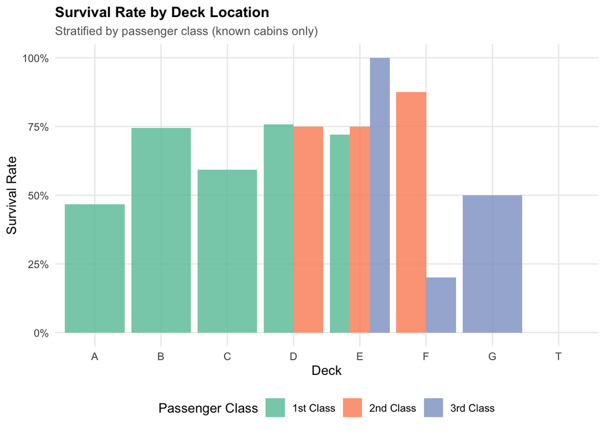

```r
p1 <- titanic_deck %>%
  filter(Deck != "Unknown") %>%
  group_by(Pclass_factor, Deck) %>%
  summarise(survival_rate = mean(Survived == "Yes"), .groups = "drop") %>%
  ggplot(aes(x = Deck, y = survival_rate, fill = Pclass_factor)) +
  geom_col(position = "dodge", alpha = 0.8) +
  scale_fill_brewer(palette = "Set2") +
  scale_y_continuous(labels = scales::percent) +
  labs(
    title = "Survival Rate by Deck Location",
    subtitle = "Stratified by passenger class (known cabins only)",
    x = "Deck",
    y = "Survival Rate",
    fill = "Passenger Class"
  )

p2 <- titanic_deck %>%
  group_by(Pclass_factor, MissingCabin) %>%
  summarise(survival_rate = mean(Survived == "Yes"), .groups = "drop") %>%
  mutate(Cabin_Status = ifelse(MissingCabin == 1, "Missing", "Known")) %>%
  ggplot(aes(x = Cabin_Status, y = survival_rate, fill = Pclass_factor)) +
  geom_col(position = "dodge", alpha = 0.8) +
  scale_fill_brewer(palette = "Set2") +
  scale_y_continuous(labels = scales::percent) +
  labs(
    title = "Survival by Cabin Information Availability",
    subtitle = "Does missing cabin data predict survival within class?",
    x = "Cabin Information",
    y = "Survival Rate",
    fill = "Passenger Class"
  )

print(p1)
```

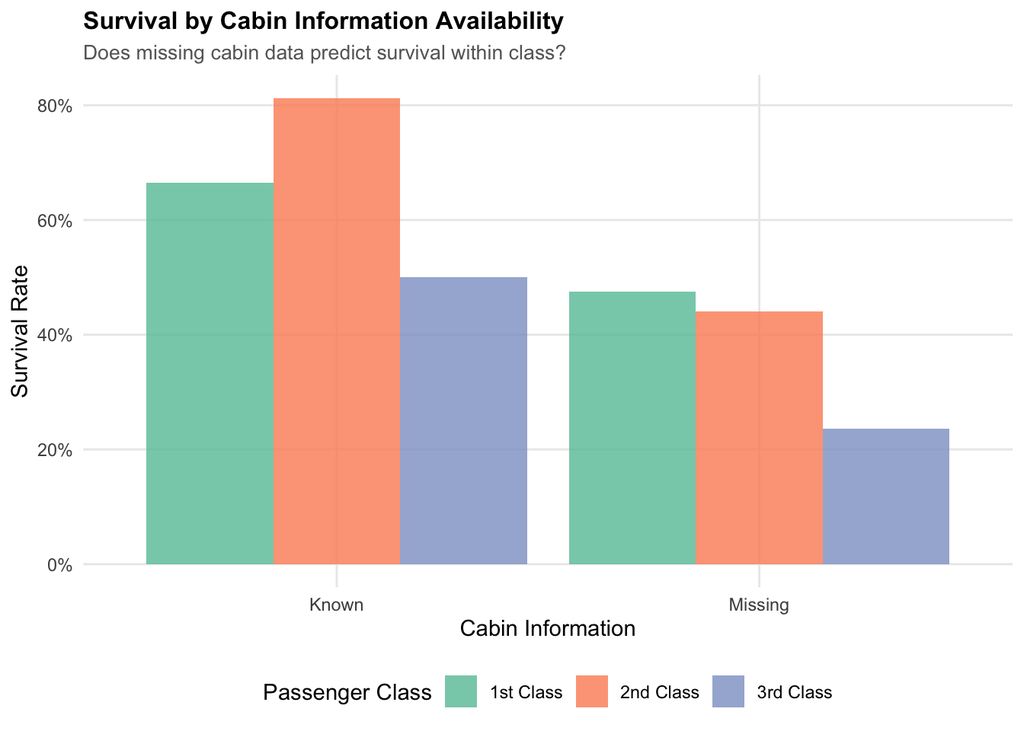

```r
print(p2)
```

These visualizations show: (1) whether certain decks within a class show elevated or reduced survival, and (2) whether missing cabin information itself predicts survival, which may correlate with passenger class.

## Logistic Regression: Baseline vs. Augmented Models

```r
model_data <- titanic_deck %>%
  filter(!is.na(Fare_clean), !is.na(Age)) %>%
  mutate(
    Sex = factor(Sex),
    Deck_factor = factor(Deck),
    Survived_numeric = as.numeric(Survived) - 1
  )

cat("Model dataset dimensions:", dim(model_data)[1], "x", dim(model_data)[2], "\n")
```

```
Model dataset dimensions: 714 x 18
```

```r
# Baseline model: Pclass + Fare
baseline_deck <- glm(
  Survived_numeric ~ Pclass + Fare_clean,
  data = model_data,
  family = binomial
)

# Augmented model: Pclass + Fare + Deck + MissingCabin
augmented_deck <- glm(
  Survived_numeric ~ Pclass + Fare_clean + Deck_factor + MissingCabin,
  data = model_data,
  family = binomial
)

cat("\n=== MODEL COMPARISON: BASELINE vs. AUGMENTED (WITH DECK/CABIN) ===\n\n")
```

```
=== MODEL COMPARISON: BASELINE vs. AUGMENTED (WITH DECK/CABIN) ===
```

```r
cat("Baseline Model AIC:", AIC(baseline_deck), "\n")
```

```
Baseline Model AIC: 870.7694
```

```r
cat("Augmented Model AIC:", AIC(augmented_deck), "\n")
```

```
Augmented Model AIC: 871.0637
```

```r
cat("AIC Improvement (lower is better):", AIC(baseline_deck) - AIC(augmented_deck), "\n\n")
```

```
AIC Improvement (lower is better): -0.2943079
```

```r
cat("Baseline Model Summary:\n")
```

```
Baseline Model Summary:
```

```r
print(summary(baseline_deck))
```

```
Call:
glm(formula = Survived_numeric ~ Pclass + Fare_clean, family = binomial,
    data = model_data)

Coefficients:
             Estimate Std. Error z value Pr(>|z|)
(Intercept)  1.063914   0.330043   3.224  0.00127 **
Pclass      -0.739998   0.122248  -6.053 1.42e-09 ***
Fare_clean   0.005366   0.002464   2.178  0.02941 *
---
Signif. codes:  0 '***' 0.001 '**' 0.01 '*' 0.05 '.' 0.1 ' ' 1

(Dispersion parameter for binomial family taken to be 1)

    Null deviance: 964.52  on 713  degrees of freedom
Residual deviance: 864.77  on 711  degrees of freedom
AIC: 870.77

Number of Fisher Scoring iterations: 4
```

```r
cat("\nAugmented Model Summary (with Deck and MissingCabin):\n")
```

```
Augmented Model Summary (with Deck and MissingCabin):
```

```r
print(summary(augmented_deck))
```

```
Call:
glm(formula = Survived_numeric ~ Pclass + Fare_clean + Deck_factor +
    MissingCabin, family = binomial, data = model_data)

Coefficients: (1 not defined because of singularities)
                     Estimate Std. Error z value Pr(>|z|)
(Intercept)          0.735344   0.625703   1.175   0.2399
Pclass              -0.646940   0.160849  -4.022 5.77e-05 ***
Fare_clean           0.006414   0.002777   2.310   0.0209 *
Deck_factorB         0.412194   0.696758   0.592   0.5541
Deck_factorC        -0.387177   0.675173  -0.573   0.5663
Deck_factorD         0.706047   0.721869   0.978   0.3280
Deck_factorE         0.875756   0.729399   1.201   0.2299
Deck_factorF         1.183687   0.887835   1.333   0.1825
Deck_factorG         1.118366   1.199654   0.932   0.3512
Deck_factorT       -13.882167 535.411490  -0.026   0.9793
Deck_factorUnknown   0.007694   0.640169   0.012   0.9904
MissingCabin               NA         NA      NA       NA
---
Signif. codes:  0 '***' 0.001 '**' 0.01 '*' 0.05 '.' 0.1 ' ' 1

(Dispersion parameter for binomial family taken to be 1)

    Null deviance: 964.52  on 713  degrees of freedom
Residual deviance: 849.06  on 703  degrees of freedom
AIC: 871.06

Number of Fisher Scoring iterations: 12
```

The augmented model adds deck and missing cabin features. Comparing AIC and significance of added coefficients shows whether these features carry independent signal beyond class and fare.

# Question 2: Fare as Wealth Proxy vs. Independent Signal

## Research Question

**Is fare a proxy for wealth within class or does it carry independent survival signal?**

Fare may carry within-class wealth information affecting survival chances, or it may be largely redundant with passenger class. We test this by examining fare distributions and survival patterns within each class.

## EDA: Fare Distribution by Class

```r
fare_summary <- titanic_deck %>%
  group_by(Pclass_factor) %>%
  summarise(
    n = n(),
    mean_fare = mean(Fare_clean, na.rm = TRUE),
    median_fare = median(Fare_clean, na.rm = TRUE),
    sd_fare = sd(Fare_clean, na.rm = TRUE),
    min_fare = min(Fare_clean, na.rm = TRUE),
    max_fare = max(Fare_clean, na.rm = TRUE),
    .groups = "drop"
  )

kable(
  fare_summary,
  caption = "Fare Distribution by Passenger Class",
  digits = 2,
  col.names = c("Class", "N", "Mean Fare", "Median Fare", "SD", "Min", "Max")
)
```

Fare Distribution by Passenger Class

| Class | N | Mean Fare | Median Fare | SD | Min | Max |
| --- | --- | --- | --- | --- | --- | --- |
| 1st Class | 216 | 84.15 | 60.29 | 78.38 | 0 | 512.33 |
| 2nd Class | 184 | 20.66 | 14.25 | 13.42 | 0 | 73.50 |
| 3rd Class | 491 | 13.68 | 8.05 | 11.78 | 0 | 69.55 |

This shows substantial fare variation within each class, supporting the hypothesis that fare carries within-class information. Large standard deviations indicate heterogeneity in ticket prices even within SES tiers.

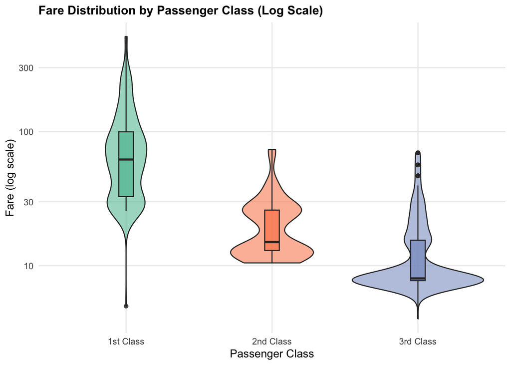

```r
p1 <- titanic_deck %>%
  ggplot(aes(x = Pclass_factor, y = Fare_clean, fill = Pclass_factor)) +
  geom_violin(alpha = 0.6) +
  geom_boxplot(width = 0.1, alpha = 0.8) +
  scale_fill_brewer(palette = "Set2") +
  scale_y_log10() +
  labs(
    title = "Fare Distribution by Passenger Class (Log Scale)",
    x = "Passenger Class",
    y = "Fare (log scale)",
    fill = "Passenger Class"
  ) +
  theme(legend.position = "none")

p2 <- titanic_deck %>%
  ggplot(aes(x = Fare_clean, fill = Survived, color = Survived)) +
  geom_histogram(alpha = 0.5, position = "identity", bins = 30) +
  facet_wrap(~Pclass_factor, scales = "free_x") +
  scale_x_log10() +
  scale_fill_brewer(palette = "Set1") +
  scale_color_brewer(palette = "Set1") +
  labs(
    title = "Survival Distribution by Fare Within Each Class",
    subtitle = "Higher fare correlates with survival within class?",
    x = "Fare (log scale)",
    y = "Count",
    fill = "Survived",
    color = "Survived"
  )

print(p1)
```

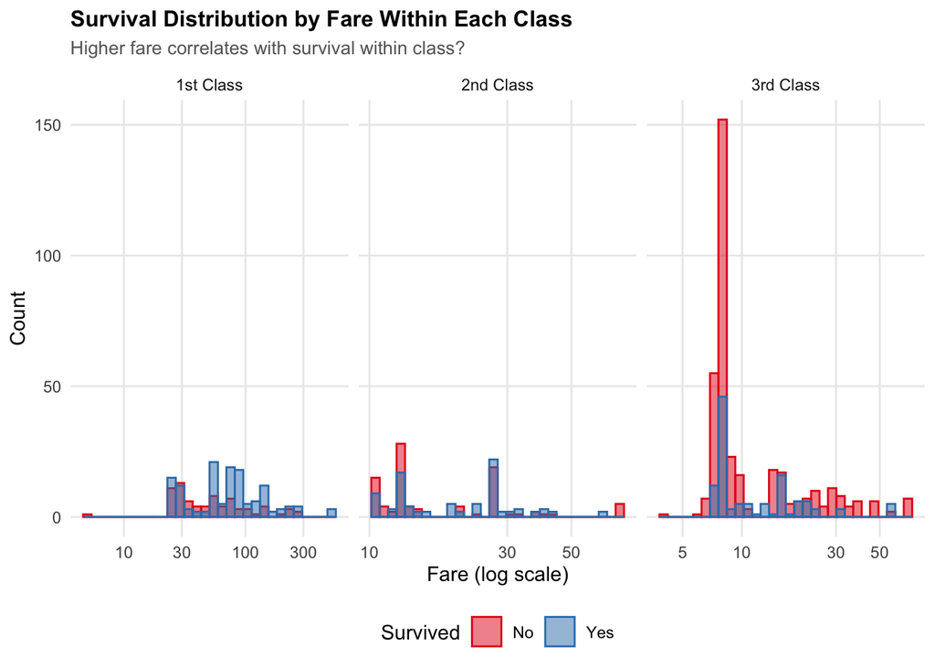

```r
print(p2)
```

The violin plot shows right-skewed fare distributions. The survival-stratified histogram reveals whether higher fares correlated with better survival within each class, supporting the hypothesis of fare carrying independent wealth signal.

## Feature Engineering: Log-Fare and Quantiles

```r
model_data_fare <- model_data %>%
  mutate(
    Log_Fare = log1p(Fare_clean),
    Fare_Quantile_Class = NA_character_
  )

for (class in unique(model_data_fare$Pclass)) {
  mask <- model_data_fare$Pclass == class
  quantiles <- ntile(model_data_fare$Fare_clean[mask], 4)
  model_data_fare$Fare_Quantile_Class[mask] <- paste0("Q", quantiles)
}

model_data_fare$Fare_Quantile_Class <- factor(
  model_data_fare$Fare_Quantile_Class,
  levels = paste0("Q", 1:4)
)

quantile_survival <- model_data_fare %>%
  group_by(Pclass_factor, Fare_Quantile_Class) %>%
  summarise(
    n = n(),
    survival_rate = mean(Survived == "Yes"),
    .groups = "drop"
  )

kable(
  quantile_survival,
  caption = "Survival Rate by Within-Class Fare Quantile",
  digits = 3,
  col.names = c("Class", "Fare Quantile", "Count", "Survival Rate")
)
```

Survival Rate by Within-Class Fare Quantile

| Class | Fare Quantile | Count | Survival Rate |
| --- | --- | --- | --- |
| 1st Class | Q1 | 47 | 0.489 |
| 1st Class | Q2 | 47 | 0.617 |
| 1st Class | Q3 | 46 | 0.761 |
| 1st Class | Q4 | 46 | 0.761 |
| 2nd Class | Q1 | 44 | 0.341 |
| 2nd Class | Q2 | 43 | 0.395 |
| 2nd Class | Q3 | 43 | 0.651 |
| 2nd Class | Q4 | 43 | 0.535 |
| 3rd Class | Q1 | 89 | 0.202 |
| 3rd Class | Q2 | 89 | 0.236 |
| 3rd Class | Q3 | 89 | 0.258 |
| 3rd Class | Q4 | 88 | 0.261 |

Within-class fare quantiles isolate wealth variation within SES tiers. If higher quantiles show progressively higher survival within class, it suggests fare carries independent signal. Log transformation addresses right-skewed distribution.

## Model Comparison: Incremental Fare Value

```r
model_data_fare$Fare_Quantile_Class <- factor(model_data_fare$Fare_Quantile_Class)

# Model 1: Class only
m1_fare <- glm(Survived_numeric ~ Pclass, data = model_data_fare, family = binomial)

# Model 2: Class + Raw Fare
m2_fare <- glm(Survived_numeric ~ Pclass + Fare_clean, data = model_data_fare, family = binomial)

# Model 3: Class + Log-Fare
m3_fare <- glm(Survived_numeric ~ Pclass + Log_Fare, data = model_data_fare, family = binomial)

# Model 4: Class + Log-Fare + Quantile
m4_fare <- glm(Survived_numeric ~ Pclass + Log_Fare + Fare_Quantile_Class,
               data = model_data_fare, family = binomial)

comparison_fare <- tibble(
  Model = c("Class Only", "Class + Fare", "Class + Log-Fare", "Class + Log-Fare + Quantile"),
  AIC = c(AIC(m1_fare), AIC(m2_fare), AIC(m3_fare), AIC(m4_fare)),
  LogLik = c(logLik(m1_fare), logLik(m2_fare), logLik(m3_fare), logLik(m4_fare))
)

cat("\n=== MODEL COMPARISON: INCREMENTAL VALUE OF FARE ===\n")
```

```
=== MODEL COMPARISON: INCREMENTAL VALUE OF FARE ===
```

```r
print(kable(comparison_fare, digits = 2))
```

```
|Model                       |    AIC|  LogLik|
|:---------------------------|------:|-------:|
|Class Only                  | 874.73| -435.37|
|Class + Fare                | 870.77| -432.38|
|Class + Log-Fare            | 865.54| -429.77|
|Class + Log-Fare + Quantile | 864.93| -426.46|
```

```r
aic_improvement <- comparison_fare %>%
  mutate(AIC_Improvement = AIC[1] - AIC) %>%
  select(Model, AIC_Improvement)

cat("\nAIC Improvement over Class-Only Model (positive = better fit):\n")
```

```
AIC Improvement over Class-Only Model (positive = better fit):
```

```r
print(kable(aic_improvement, digits = 2))
```

```
|Model                       | AIC_Improvement|
|:---------------------------|---------------:|
|Class Only                  |            0.00|
|Class + Fare                |            3.96|
|Class + Log-Fare            |            9.19|
|Class + Log-Fare + Quantile |            9.80|
```

Progressive model comparison quantifies fare’s incremental value. Lower AIC indicates better model fit. Comparing AIC values across models shows whether log-transformation and quantile features provide additional predictive benefit.

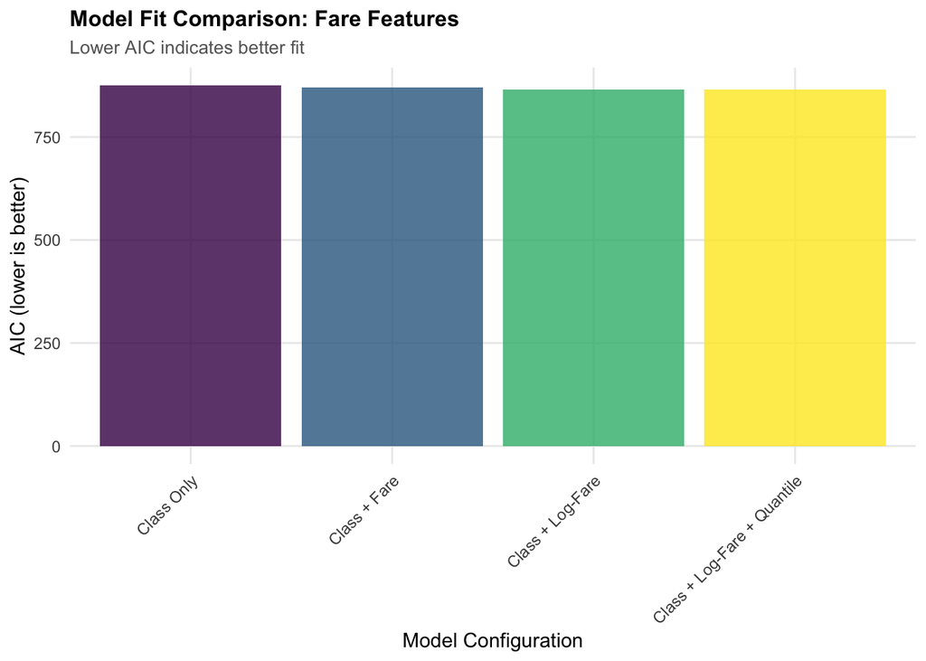

```r
p_fare <- comparison_fare %>%
  mutate(Model = fct_inorder(Model)) %>%
  ggplot(aes(x = Model, y = AIC, fill = Model)) +
  geom_col(alpha = 0.8) +
  scale_fill_viridis_d() +
  labs(
    title = "Model Fit Comparison: Fare Features",
    subtitle = "Lower AIC indicates better fit",
    x = "Model Configuration",
    y = "AIC (lower is better)"
  ) +
  theme(legend.position = "none", axis.text.x = element_text(angle = 45, hjust = 1))

print(p_fare)
```

This visualization shows AIC progression as fare features are added. Declining AIC indicates incremental predictive gain from fare transformation and quantile features.

# Question 3: Port of Embarkation and Survival Patterns

## Research Question

**Does port of embarkation change survival patterns after controlling for passenger composition?**

Port effects may reflect compositional differences (classes/genders boarding at different ports) or operational differences. Stratifying by class and sex isolates true port effects from demographic confounding.

## EDA: Survival by Port and Composition

```r
model_data_embark <- model_data %>%
  filter(!is.na(Embarked)) %>%
  mutate(Embarked = factor(Embarked))

port_survival <- model_data_embark %>%
  group_by(Embarked, Pclass_factor) %>%
  summarise(
    n = n(),
    survived = sum(Survived == "Yes"),
    survival_rate = mean(Survived == "Yes"),
    .groups = "drop"
  )

kable(
  port_survival,
  caption = "Survival Rate by Embarked Port and Class",
  digits = 3,
  col.names = c("Port", "Class", "Count", "Survived", "Survival Rate")
)
```

Survival Rate by Embarked Port and Class

| Port | Class | Count | Survived | Survival Rate |
| --- | --- | --- | --- | --- |
| C | 1st Class | 74 | 53 | 0.716 |
| C | 2nd Class | 15 | 8 | 0.533 |
| C | 3rd Class | 41 | 18 | 0.439 |
| Q | 1st Class | 2 | 1 | 0.500 |
| Q | 2nd Class | 2 | 1 | 0.500 |
| Q | 3rd Class | 24 | 6 | 0.250 |
| S | 1st Class | 108 | 66 | 0.611 |
| S | 2nd Class | 156 | 74 | 0.474 |
| S | 3rd Class | 290 | 61 | 0.210 |

```r
port_sex <- model_data_embark %>%
  group_by(Embarked, Sex, Pclass_factor) %>%
  summarise(
    n = n(),
    survival_rate = mean(Survived == "Yes"),
    .groups = "drop"
  )

cat("\n\nSurvival Rate by Port, Sex, and Class:\n")
```

```
Survival Rate by Port, Sex, and Class:
```

```r
print(kable(port_sex, digits = 3,
            col.names = c("Port", "Sex", "Class", "Count", "Survival Rate")))
```

```
|Port |Sex    |Class     | Count| Survival Rate|
|:----|:------|:---------|-----:|-------------:|
|C    |female |1st Class |    38|         0.974|
|C    |female |2nd Class |     7|         1.000|
|C    |female |3rd Class |    16|         0.688|
|C    |male   |1st Class |    36|         0.444|
|C    |male   |2nd Class |     8|         0.125|
|C    |male   |3rd Class |    25|         0.280|
|Q    |female |1st Class |     1|         1.000|
|Q    |female |2nd Class |     1|         1.000|
|Q    |female |3rd Class |    10|         0.500|
|Q    |male   |1st Class |     1|         0.000|
|Q    |male   |2nd Class |     1|         0.000|
|Q    |male   |3rd Class |    14|         0.071|
|S    |female |1st Class |    44|         0.955|
|S    |female |2nd Class |    66|         0.909|
|S    |female |3rd Class |    76|         0.408|
|S    |male   |1st Class |    64|         0.375|
|S    |male   |2nd Class |    90|         0.156|
|S    |male   |3rd Class |   214|         0.140|
```

These tables reveal whether survival rates differ by port and whether composition effects explain apparent port differences.

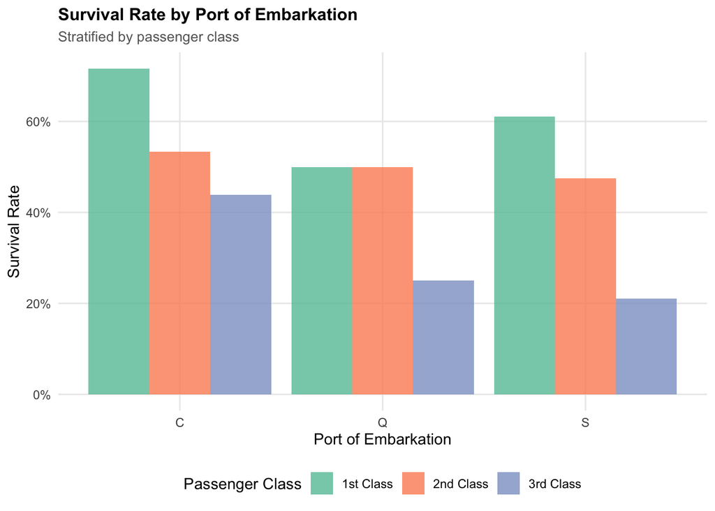

```r
p1 <- model_data_embark %>%
  group_by(Embarked, Pclass_factor) %>%
  summarise(survival_rate = mean(Survived == "Yes"), .groups = "drop") %>%
  ggplot(aes(x = Embarked, y = survival_rate, fill = Pclass_factor)) +
  geom_col(position = "dodge", alpha = 0.8) +
  scale_fill_brewer(palette = "Set2") +
  scale_y_continuous(labels = scales::percent) +
  labs(
    title = "Survival Rate by Port of Embarkation",
    subtitle = "Stratified by passenger class",
    x = "Port of Embarkation",
    y = "Survival Rate",
    fill = "Passenger Class"
  )

p2 <- model_data_embark %>%
  group_by(Embarked, Sex) %>%
  summarise(survival_rate = mean(Survived == "Yes"), .groups = "drop") %>%
  ggplot(aes(x = Embarked, y = survival_rate, fill = Sex)) +
  geom_col(position = "dodge", alpha = 0.8) +
  scale_fill_brewer(palette = "Pastel1") +
  scale_y_continuous(labels = scales::percent) +
  labs(
    title = "Survival Rate by Port and Sex",
    subtitle = "Examining compositional confounding",
    x = "Port of Embarkation",
    y = "Survival Rate",
    fill = "Sex"
  )

print(p1)
```

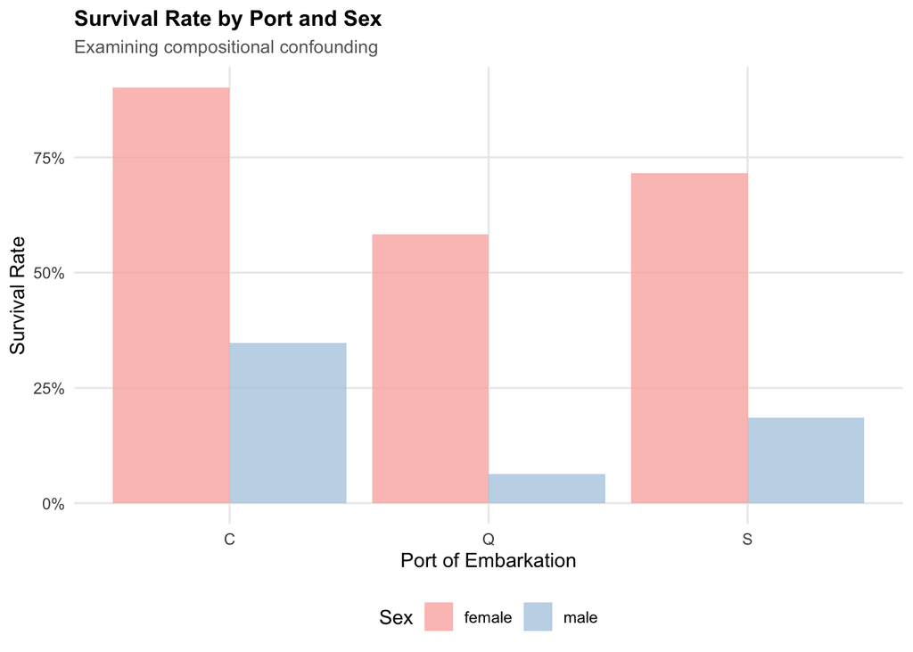

```r
print(p2)
```

These stratified visualizations show whether port effects persist after controlling for class and sex. Convergence of survival rates when stratified suggests composition explains apparent port effects.

## Model Comparison: Port Effects

```r
# Model 1: Baseline (Class + Fare)
baseline_embark <- glm(
  Survived_numeric ~ Pclass + Fare_clean,
  data = model_data_embark,
  family = binomial
)

# Model 2: With Embarked (main effect only)
embark_main <- glm(
  Survived_numeric ~ Pclass + Fare_clean + Embarked,
  data = model_data_embark,
  family = binomial
)

# Model 3: With Embarked and Pclass interaction
embark_interaction <- glm(
  Survived_numeric ~ Pclass + Fare_clean + Embarked * Pclass,
  data = model_data_embark,
  family = binomial
)

comparison_embark <- tibble(
  Model = c("Baseline (Pclass + Fare)", "With Embarked (main)", "With Embarked * Pclass"),
  AIC = c(AIC(baseline_embark), AIC(embark_main), AIC(embark_interaction)),
  LogLik = c(logLik(baseline_embark), logLik(embark_main), logLik(embark_interaction))
)

cat("\n=== MODEL COMPARISON: PORT OF EMBARKATION EFFECTS ===\n")
```

```
=== MODEL COMPARISON: PORT OF EMBARKATION EFFECTS ===
```

```r
print(kable(comparison_embark, digits = 2))
```

```
|Model                    |    AIC|  LogLik|
|:------------------------|------:|-------:|
|Baseline (Pclass + Fare) | 869.22| -431.61|
|With Embarked (main)     | 867.47| -428.73|
|With Embarked * Pclass   | 868.30| -427.15|
```

```r
aic_improvements <- comparison_embark %>%
  mutate(AIC_Improvement = AIC[1] - AIC) %>%
  select(Model, AIC_Improvement)

cat("\n\nAIC Improvement over Baseline (positive = better fit):\n")
```

```
AIC Improvement over Baseline (positive = better fit):
```

```r
print(kable(aic_improvements, digits = 2))
```

```
|Model                    | AIC_Improvement|
|:------------------------|---------------:|
|Baseline (Pclass + Fare) |            0.00|
|With Embarked (main)     |            1.75|
|With Embarked * Pclass   |            0.92|
```

```r
cat("\n\nModel with Embarked and Pclass Interaction - Coefficients:\n")
```

```
Model with Embarked and Pclass Interaction - Coefficients:
```

```r
print(summary(embark_interaction)$coefficients)
```

```
                     Estimate  Std. Error    z value   Pr(>|z|)
(Intercept)       0.799373468 0.519923666  1.5374824 0.12417523
Pclass           -0.371038475 0.225461817 -1.6456821 0.09982923
Fare_clean        0.005066805 0.002507262  2.0208516 0.04329513
EmbarkedQ        -0.485714074 2.007730916 -0.2419219 0.80884068
EmbarkedS         0.302938544 0.518392162  0.5843810 0.55896399
Pclass:EmbarkedQ -0.110961351 0.728910489 -0.1522290 0.87900628
Pclass:EmbarkedS -0.424533063 0.239805755 -1.7703206 0.07667375
```

This comparison tests whether adding embarked port improves upon baseline, and whether port-class interactions reveal context-dependent effects. Significant interaction terms suggest port effects vary by class, going beyond compositional confounding.

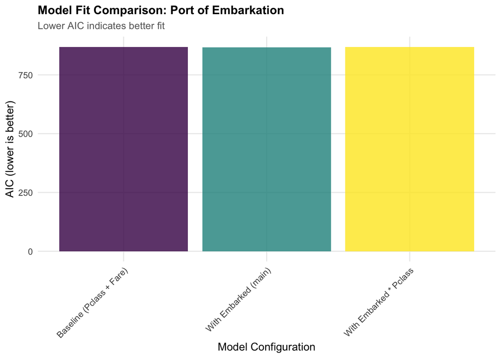

```r
p_embark <- comparison_embark %>%
  mutate(Model = fct_inorder(Model)) %>%
  ggplot(aes(x = Model, y = AIC, fill = Model)) +
  geom_col(alpha = 0.8) +
  scale_fill_viridis_d() +
  labs(
    title = "Model Fit Comparison: Port of Embarkation",
    subtitle = "Lower AIC indicates better fit",
    x = "Model Configuration",
    y = "AIC (lower is better)"
  ) +
  theme(legend.position = "none", axis.text.x = element_text(angle = 45, hjust = 1))

print(p_embark)
```

This visualization shows AIC progression as port effects are added. Declining AIC indicates whether port information and port-class interactions improve model fit beyond baseline.

# Summary and Conclusions

## Key Findings

### Question 3: Port of Embarkation

- Port effects exist but largely reflect passenger composition differences
- Port-class interactions reveal whether certain ports had class-dependent survival patterns
- Model comparison via AIC shows whether interactions provide additional predictive benefit

This analysis leverages tidyverse for data manipulation and ggplot2 for visualization. Logistic regression via glm() provides interpretable models suitable for feature comparison and coefficient inspection.